# Appendix I: Statistical Foundations for scRNA-seq

Author

Single Cell RNA-seq Workshop

This appendix is a working reference for the statistics actually used by the workshop’s lectures and tutorials. It assumes a beginning grad student who took an undergraduate stats course — distributions, regression, p-values — but has rust on the specifics.

# 1. Counts, distributions, and why we need them

scRNA-seq data are **integer counts**. Counts are *not* continuous — you can’t have 4.7 UMIs of a gene. So the standard Normal-distribution toolkit (t-tests, linear regression on the raw counts) doesn’t apply directly. We need distributions defined on integers.

## The Poisson distribution — counts under “perfect” sampling

If a cell has $\mu$ true molecules of gene X and we sample uniformly, the count we observe follows a **Poisson** distribution:

$$P(K = k) = \frac{e^{-\mu}\mu^k}{k!}$$

Key Poisson facts:

- Mean = $\mu$
- **Variance = $\mu$** (variance equals the mean — the defining property)
- Two parameters? No. Just one: $\mu$

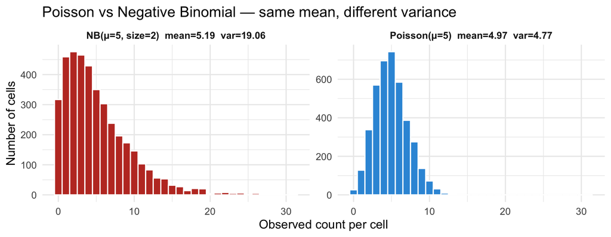

The Poisson is what you’d get if every cell with the same “mean” had counts that *only* varied because of sampling noise. **Real RNA-seq data has more spread than Poisson predicts** — the variance is *bigger* than the mean. This is called **over-dispersion**.

## The negative binomial — counts with biological + technical variance

The **negative binomial (NB)** adds a second parameter to handle over-dispersion. With mean $\mu$ and dispersion $\phi$, its variance is:

$$\text{Var}(K) = \mu + \frac{\mu^2}{\phi}$$

- As $\phi \to \infty$, variance → $\mu$ — NB collapses back to Poisson
- For finite $\phi$, variance is **larger** than mean. The smaller $\phi$, the more over-dispersion
- DESeq2’s `dispersion` parameter is essentially $1/\phi$ — bigger DESeq2 dispersion = more over-dispersed

**Tip**

**The single most important fact about scRNA-seq distributions.** UMI counts are over-dispersed. Always. Tools that assume Poisson (very few do; Naïve t-tests definitely don’t even assume that) underestimate the variance and produce **anti-conservative p-values** — false positives. The negative binomial is the right default.

# 2. Mean-variance relationships

If you plot **log(variance)** vs **log(mean)** for every gene in a real RNA-seq dataset, you don’t see a flat line — you see a structured curve.

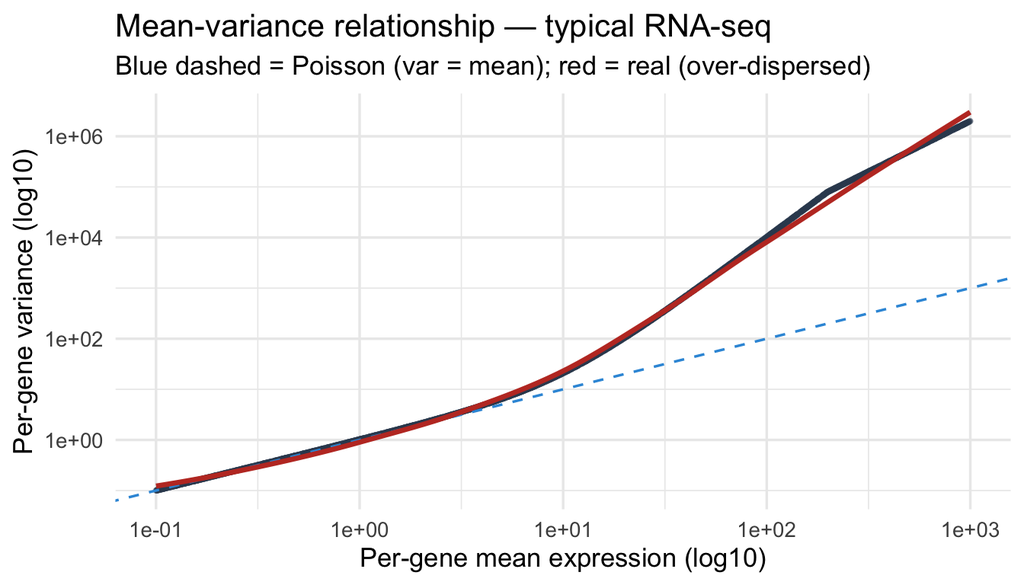

Key observations:

- The Poisson line (variance = mean, blue dashed) is the **lower bound**. Real genes are at or above it
- Low-mean genes are roughly Poisson; high-mean genes have far more variance than Poisson predicts. That’s the over-dispersion
- DESeq2 / edgeR / limma-voom **fit a curve to this relationship** to estimate per-gene dispersion. They use the curve as a prior to **shrink** noisy single-gene estimates toward the trend

This is why those tools work better than per-gene Wald tests for low-count datasets: they borrow strength across genes.

# 3. Normalization

Each cell has a different total UMI count (its **library size** or **sequencing depth**). A cell with 20,000 UMIs across all genes will have larger gene-level counts than a cell with 5,000 UMIs, even if the cells have identical biology. Normalization removes this technical variance.

## Size-factor normalization (DESeq2 / edgeR)

For each cell $j$, compute a **size factor** $s_j$ that scales away differences in total depth. Then the normalized count is:

$$\tilde y_{ij} = \frac{y_{ij}}{s_j}$$

DESeq2’s “median of ratios” estimator is the standard. The crucial property: it’s **robust** — a few highly-expressed genes don’t dominate the size factor.

## Log-normalization (Seurat default)

Seurat’s `NormalizeData()` does:

$$\tilde y_{ij} = \log_2\left(\frac{y_{ij}}{C_j} \cdot 10000 + 1\right)$$

where $C_j$ is the cell’s total UMI count. This is “log of CPM-like” — and the `+1` keeps zeros mapping to zero (otherwise `log(0)` is undefined).

## SCTransform — variance-stabilizing transform

`SCTransform()` fits a per-gene NB regression on the raw counts as a function of cell depth, then uses the **Pearson residuals** as the normalized values. The residuals have approximately constant variance across the mean-expression range, which makes downstream PCA / clustering more stable.

# 4. The design matrix and linear models

When DESeq2 runs `~ condition` or `~ donor + condition`, it’s fitting a **generalized linear model (GLM)** with a negative-binomial likelihood:

$$\log(\mu_{ij}) = X_j^\top \beta_i$$

where:

- $\mu_{ij}$ is the expected count of gene $i$ in sample $j$
- $X_j$ is the **design matrix row** for sample $j$ — encodes “which condition is this?”, “which donor?”, “what’s the batch?”
- $\beta_i$ is the per-gene coefficient vector — what we want to estimate

For `~ condition` with two levels (`CTRL`, `STIM`), $X_j$ is a 2-column matrix:

| sample_id | condition | (Intercept) | conditionSTIM |
| --- | --- | --- | --- |
| CTRL_1 | CTRL | 1 | 0 |
| CTRL_2 | CTRL | 1 | 0 |
| CTRL_3 | CTRL | 1 | 0 |
| CTRL_4 | CTRL | 1 | 0 |
| STIM_1 | STIM | 1 | 1 |
| STIM_2 | STIM | 1 | 1 |
| STIM_3 | STIM | 1 | 1 |
| STIM_4 | STIM | 1 | 1 |

The `(Intercept)` column is all 1s; the `conditionSTIM` column is 0 for CTRL and 1 for STIM. The fitted $\beta$ for the `conditionSTIM` coefficient is the **log-fold-change** of STIM vs CTRL, *on the natural log scale*.

**Warning**

**`log2FoldChange` vs `log_2`-coefficient**. DESeq2 reports `log2FoldChange` (base-2 logarithm); your $\beta$ from `glm()` is on the natural-log scale. Multiply by $1/\ln 2 \approx 1.44$ to convert. DESeq2 handles this automatically — but if you ever fit a GLM yourself, watch the units.

# 5. Hypothesis testing — Wald, LRT, p-values

DESeq2’s default is the **Wald test** for each coefficient:

$$z = \frac{\hat\beta - 0}{\hat{SE}(\hat\beta)}$$

If the model is correct and the coefficient is truly zero, $z$ is approximately standard normal. Most pipelines convert to a p-value via the normal distribution.

A more powerful (but slower) alternative is the **likelihood ratio test (LRT)**: fit the full model with `~ donor + condition`, fit a reduced model with `~ donor`, and compare their likelihoods. Useful for testing whether *all* levels of a factor matter, not just one.

## What p-values mean (and don’t mean)

- A p-value is the probability of seeing a result *at least this extreme* if the null hypothesis is true. Period.
- **Not** the probability the null is true given the data
- **Not** the probability you’d get the same result on replication
- A small p-value tells you the data are unlikely under the null. It tells you nothing about the magnitude of the effect — that’s what `log2FoldChange` is for

# 6. The multiple-testing problem and FDR

If you test 10,000 genes at $\alpha = 0.05$ and the null is true for all of them, you’d expect 500 false positives by chance. That’s unusable.

The fix is **multiple-testing correction**. The two main approaches:

| Method | Controls | Strictness |
| --- | --- | --- |
| **Bonferroni** | Family-wise error rate (FWER) — probability of *any* false positive across all tests | Very strict — divide $\alpha$ by the number of tests |
| **Benjamini-Hochberg (BH)** | False discovery rate (FDR) — expected fraction of “significant” hits that are false positives | Less strict — controls the *proportion* of false positives among rejections |

DESeq2’s `padj` column is the BH-corrected p-value. **Filter on `padj < 0.05` to control FDR at 5%**, meaning you accept that ~5% of your hits will be false positives.

**Tip**

**The intuition for FDR.** If your DE list has 200 genes at `padj < 0.05`, expect about 10 to be wrong. That’s usually a fine bargain. Bonferroni would let you keep maybe 20 with rock-solid certainty — much more conservative, and most often more conservative than what biology requires.

# 7. Shrinkage and why it matters

A gene with `baseMean = 2` has very few reads to estimate effect size from. Its raw `log2FoldChange` is enormous and noisy — totally driven by sampling luck. If you sort by raw LFC, you get a top-10 list of garbage low-count genes.

**Shrinkage** pulls noisy estimates toward a common prior:

$$\beta_{shrunk} = w \cdot \beta_{raw} + (1 - w) \cdot 0$$

where $w$ depends on how confident the estimate is. High-count, high-confidence genes barely shrink; low-count, noisy genes shrink toward zero.

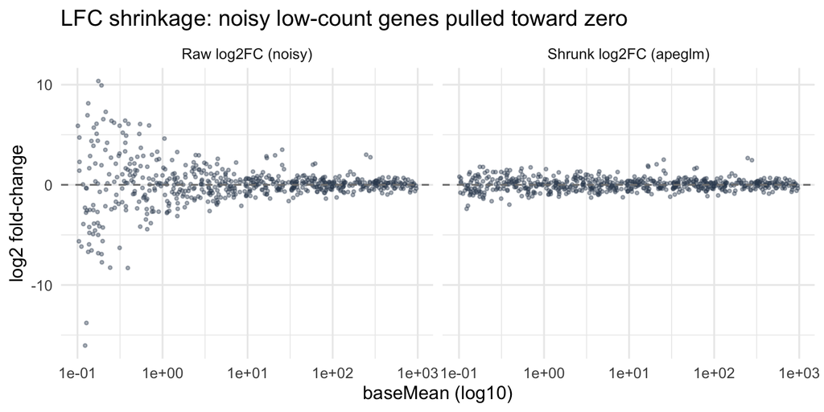

Key tools:

- **`apeglm`** — DESeq2’s recommended shrinkage estimator (Zhu *et al.* 2019). The default for `lfcShrink()`
- **`ashr`** — adaptive shrinkage. Also good. Sometimes more shrinkage on weak signals
- **`normal`** — DESeq2’s older shrinkage. Don’t use unless the others fail

**Tip**

**Always shrink LFCs before ranking or making volcano plots.** Otherwise your “top hits” are dominated by low-count noise. `lfcShrink()` is one extra line of code.

# 8. Why per-cell tests are wrong for condition contrasts

This is the single most-violated rule in scRNA-seq.

The setup: you have 4 donors per condition (treated vs control), each contributing ~3,000 cells to the analysis. Total: 24,000 cells. You want to know which genes change with treatment in `CD14 Mono` cells.

**Right:** sum the per-cell counts to get a (donor × condition) **pseudobulk** matrix — 8 columns, one per donor. Run DESeq2 on the pseudobulk with `~ condition`. With $N = 8$, the test is honest.

**Important**

**Per-cell tests are fine for *exploratory marker discovery*** (e.g. “what’s a marker for cluster 7?”) because you’re not making a condition claim — you’re just listing genes that distinguish a cluster. They are **not** valid for condition contrasts, period. See Squair *et al.* 2021 for the empirical demonstration.

# 9. Variance partitioning — what does “explained” mean?

Concept that comes up in PCA, batch-effect diagnostics, and integration metrics.

**Total variance** of a dataset can be decomposed into:

$$\text{Var(total)} = \text{Var(biological)} + \text{Var(technical)} + \text{Var(noise)}$$

Each PC explains some fraction of the total. The **scree plot** shows what fraction each PC explains. The **elbow** is where additional PCs stop explaining biology and start explaining noise.

For integration: a “good” integrated reduction has biological variance preserved (cells of the same type cluster) and technical variance removed (cells from the same donor *don’t* cluster). LISI / k-BET / silhouette scores quantify this trade-off.

# 10. The Bayesian shadow on shrinkage

DESeq2’s shrinkage estimators are technically Bayesian. The “prior” is the fitted dispersion-vs-mean curve; each gene’s per-gene estimate is the “data”; the shrunk estimate is the posterior mean.

You don’t need to think Bayesian to use DESeq2. But it helps to know that:

- The dispersion shrinkage is informed by *all* genes — the whole dataset is the prior
- `apeglm` shrinks LFCs toward zero — its prior is “most genes don’t change much”
- A Bayesian framework is also why `padj = NA` for some genes — DESeq2 prunes genes whose data are insufficient to update the prior meaningfully

If you want to dive in, the canonical text is Gelman, Carlin, Stern et al. (2013) *Bayesian Data Analysis*.

# 11. Statistical literacy checklist

You’re stats-ready for the workshop if you can answer these without looking:

1. Why is the negative binomial used instead of Poisson for RNA-seq?
2. What does a size factor do? Why does DESeq2 need one?
3. What is `padj` adjusting for, and what does FDR mean?
4. Why do we *shrink* log-fold-changes before ranking?
5. Why is per-cell DE statistically wrong for condition contrasts?
6. What is the difference between the Wald test and the LRT?
7. What does “over-dispersion” mean numerically?

If any of these are foggy, re-read the section and the answer becomes obvious.

# 12. Going further

- **Holmes & Huber** — *Modern Statistics for Modern Biology* — free online at https://www.huber.embl.de/msmb/. Chapters 3 (NB / Poisson), 6 (testing), 9 (clustering) are directly relevant
- **Gelman, Hill, Vehtari** — *Regression and Other Stories* — for the regression / GLM mindset
- **Wilks** — *Statistical Methods in the Atmospheric Sciences* — surprisingly good chapters on hypothesis testing for non-statisticians (chapter 5)
- **Squair et al. 2021** — the canonical paper on why per-cell DE goes wrong, [doi:10.1038/s41467-021-25960-2](https://doi.org/10.1038/s41467-021-25960-2)
- **Love, Huber & Anders 2014** — DESeq2 paper, [doi:10.1186/s13059-014-0550-8](https://doi.org/10.1186/s13059-014-0550-8)

## See also

- Lecture 05 — DESeq2: Bulk Fundamentals + Pseudobulk DE — the workshop’s primary applied DE lecture
- Tutorial 05 — DESeq2: Bulk Primer + Pseudobulk DE — bulk DESeq2 walkthrough
- Tutorial 05 — DESeq2: Bulk Primer + Pseudobulk DE — DESeq2 on pseudobulk single-cell counts
- Glossary — for definitions of FDR, dispersion, etc.

Back to top